# STAT545-hw01-Uduman-Aisha

## Hi my name is Aisha

**I’m a MSc student in Forestry and part of the [Wildlife Coexistence lab](http://wildlife.forestry.ubc.ca)** :evergreen_tree: :whale2: :herb: :leopard: :palm_tree: :elephant: :deciduous_tree: :beetle: :tiger2:

[figure not shown]

something to think about

> “Only when the last tree has been cut down, the last fish been caught, and the last stream poisoned, will we realize we cannot eat money.”

> Cree Indian philopshy

#### This is Kaaya, my super-mutt of a dog :wolf:

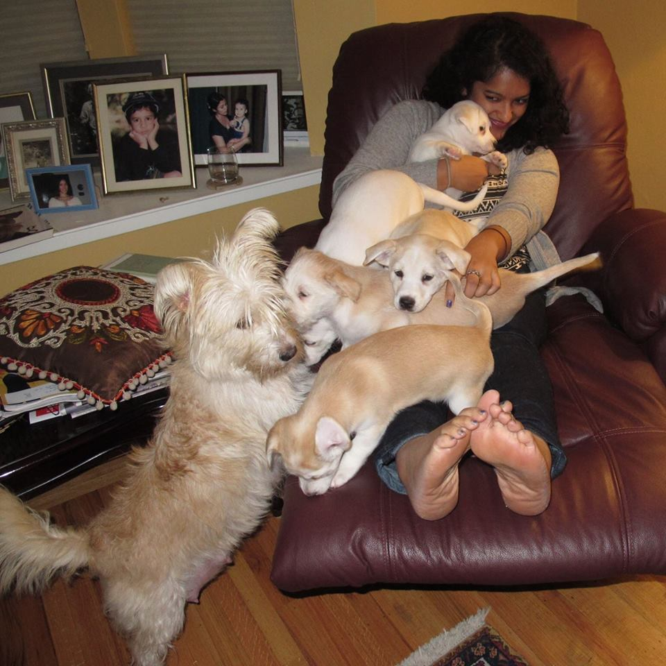

She was adopted from Prince Albert National Park in northern Saskatchewan, and turned out to be pregnant! She was an awesome mum and regularly visits her pups.

#### Other things I like apart from dogs:

- Hikes
- Wildlife
- FOOD
- Stones
- Judo
- Jazz

#### Reporting my process

This is my first time using R, Git, Github etc. so it’s a steep learning curve. I made changes to this README.md file using R, editing locally, then saving, committing and pushing to Github. For the R Markdown document I went through what we learned in class, and made some slight changes to explore other tools and processes I could do in R.

Issues I had were making the images smaller in size and isolating a country out of the gapminder data - I tried to look at just Chile but errors kept coming up.